# Assignment 2: Data visualization

Tamas Nagy

You will have to create 3 plots based on the datasets and instructions detailed below. You will find the plots themeselves in the `assignments/assignment_2_plots`. Your task is to write the code that will reproduce the plots as closely as possible.

# Skills needed to solve this assignment

- Using R and RStudio, reading data
- Reporting using RMarkdown
- Using Git and Github (for submitting the task)
- Data manipulation (e.g. dplyr, tidyr), and working with factors (forcats)
- Data visuzlization (ggplot2)

## Task 1: Climbing expeditions

The 2020-09-22 TidyTueday datasets are about climbing expeditions. From the three datasets, use the “expeditions”. Reproduce the plot below! Notice a few things:

- Use `forcats::fct_lump()` to get the 15 most frequent peaks, and drop the “Other” category.
- The bars are ordered by the sum of all expeditions (use `fct_reorder()`).
- The bar colors use the viridis palette and light theme.

```r
expeditions <- readr::read_csv('https://raw.githubusercontent.com/rfordatascience/tidytuesday/main/data/2020/2020-09-22/expeditions.csv')
expeditions %>%
  group_by(peak_name) %>%
  count(season)
```

```
## # A tibble: 715 × 3
## # Groups:   peak_name [391]
##    peak_name     season     n
##    <chr>         <chr>  <int>
##  1 Aichyn        Autumn     3
##  2 Ama Dablam    Autumn  1066
##  3 Ama Dablam    Spring   229
##  4 Ama Dablam    Winter    71
##  5 Amotsang      Autumn     2
##  6 Amphu Gyabjen Spring     3
##  7 Amphu I       Autumn     2
##  8 Amphu Middle  Spring     1
##  9 Anidesh Chuli Spring     2
## 10 Annapurna I   Autumn    85
## # ℹ 705 more rows
```

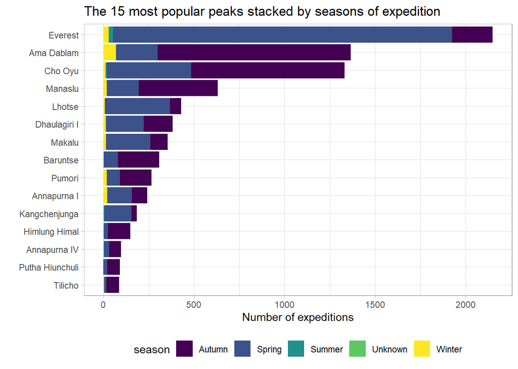

```r
top15withother <- expeditions %>%
  mutate(peak_name = fct_lump(peak_name, n = 15)) %>%
  count(peak_name, season) %>%
  group_by(peak_name) %>%
  mutate(total = sum(n)) %>%
  arrange(desc(total), peak_name, season)

top15withother <- expeditions %>%
  mutate(peak_name = fct_lump(peak_name, n = 15)) %>%
  count(peak_name, sort = TRUE) %>%
    left_join(
    expeditions %>%
      group_by(peak_name) %>%
      count(season),
    by = "peak_name")


seasonstop15wo <- top15withother %>%
  pivot_wider(
    names_from = season,
    values_from = n.y
  )

top15 <- seasonstop15wo[-c(1,17), ]


top15_long <- top15 %>%
  pivot_longer(cols = c(Autumn, Spring, Summer, Winter, Unknown),
               names_to = "season",
               values_to = "count")

top15_long %>%
  mutate(peak_name = fct_reorder(peak_name, n.x)) %>%
  ggplot(aes(x = peak_name, y = count, fill = season)) +
  geom_bar(stat = "identity") +
  scale_fill_viridis(discrete = TRUE) +
  xlab("") +
  ylab("Number of expeditions") +
  theme_light() +
  ggtitle("The 15 most popular peaks stacked by seasons of expedition") +
  coord_flip() +
  theme(legend.position = "bottom")
```

## Task 2: PhDs awarded

The 2019-02-19 TidyTueday dataset is about phd-s awarded by year and field. There is only one dataset, it is called `phd_by_field`. Reproduce the plot below!

Notes:

- First you have to aggregate the data to count all phd-s by broad fields.
- To make the x axis breaks pretty, use `scales::pretty_breaks()`, to make the y axis labels comma formatted, use `scales::comma_format()`.
- The line size is 1.2, the colors are from the brewer “Dark2” palette. The theme is set to minimal.

```r
phddata <- readr::read_csv("https://raw.githubusercontent.com/rfordatascience/tidytuesday/refs/heads/main/data/2019/2019-02-19/phd_by_field.csv")
```

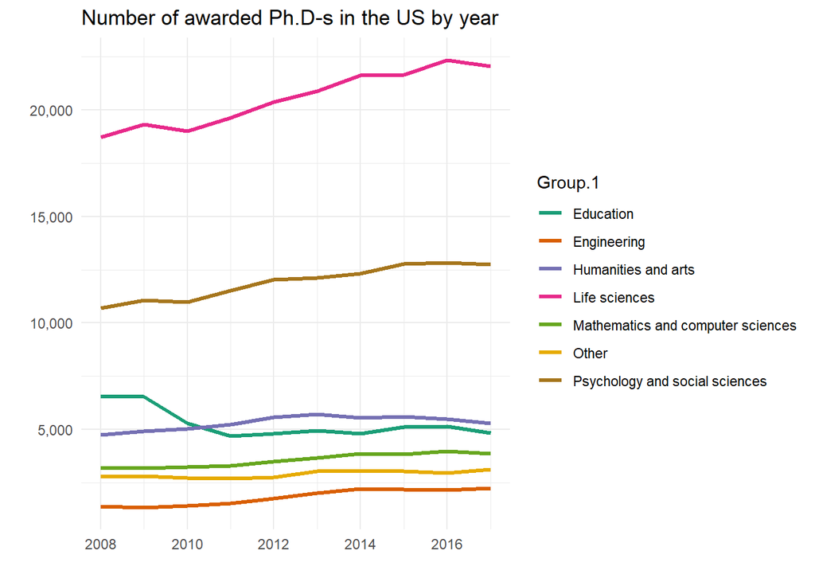

```r
phddata <- na.omit(phddata)

phdplot <- aggregate(phddata$n_phds, by = list(phddata$broad_field, phddata$year), sum)

phdplot %>%
  ggplot(
    aes(x = Group.2, y = x)) +
    geom_line(aes(color = Group.1, ),linewidth = 1.2 ) +
    theme_minimal() +
    ggtitle("Number of awarded Ph.D-s in the US by year") +
    xlab("") +
    ylab("") +
    scale_x_continuous(breaks = breaks_pretty(5)) +
    scale_y_continuous(labels = scales::comma) +
    scale_color_brewer(palette = "Dark2")
```

## Task 3: Commute in the US

The 2019-11-05 TidyTueday dataset is about commuting to work in each city in the US by bike or on foot. There is only one dataset, it is called `commute`. Reproduce the plot below!

Notes:

- First you have to aggregate the data to count all commutes by state.
- Both axis scales are log transformed and the labels comma formatted, using `scales::comma_format()`
- The point size is 2, . The theme is set to light.

```r
commute_mode <- readr::read_csv("https://raw.githubusercontent.com/rfordatascience/tidytuesday/main/data/2019/2019-11-05/commute.csv")
```

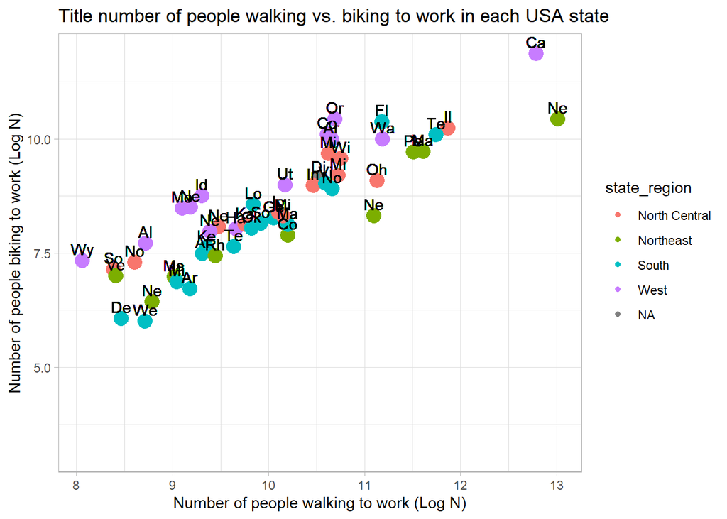

```r
commute_data <- aggregate(commute_mode$n, by = list(commute_mode$mode, commute_mode$state), sum)


commute_data_bike_walk <- commute_data %>%
  pivot_wider(
    names_from = Group.1,
    values_from =  x
  )
commute_data_bike_walk <- as.data.frame(commute_data_bike_walk)

colnames(commute_data_bike_walk)[colnames(commute_data_bike_walk) == "Group.2"] <- "state"

commute_final <- merge(commute_data_bike_walk, commute_mode, by = "state", all.x = TRUE)

commute_final <- subset(commute_final, state != "Ca") # there was only one Ca row in the original dataset so I had to exclude it to be able to make the chart.


ggplot(commute_final, aes(x= log(Walk), y=log(Bike), color = state_region)) +
  geom_point(aes(size = 2)) +
  theme_light() +
  ylab("Number of people biking to work (Log N)") +
  xlab("Number of people walking to work (Log N)") +
  guides(size = "none") +
  ggtitle("Title number of people walking vs. biking to work in each USA state") +
  geom_text(aes(label = substr(state, 1, 2)), color = "black", vjust = -0.5)
```